# Final Project - Excel version

### Analyzing Correlations in the Top 10 Happiness Score Countries

#### Pull Top 10 Countries

= Table.Sort(#“Renamed Columns”,{{“ladder_score”, Order.Descending}})

#### Remove Country names

= Table.SelectRows(#“Filtered Rows3”, each [country] <> null and [country] <> ““)

Matrix calculated using CORREL function in Excel with indexing to repeat according to columns.

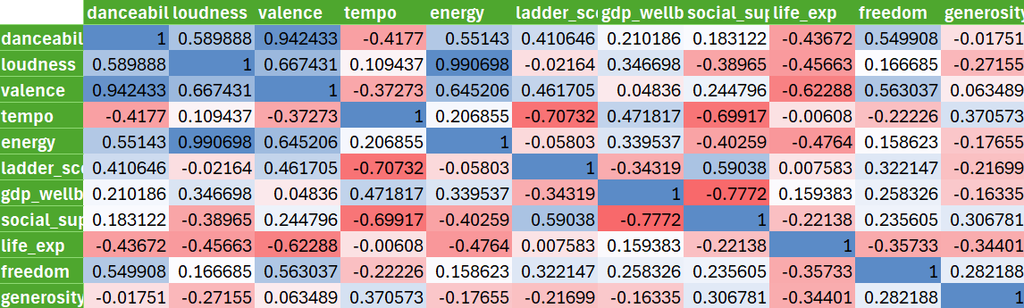

= Table.UnpivotOtherColumns(#“Changed Type”, {“Column1”}, “Attribute”, “Value”)

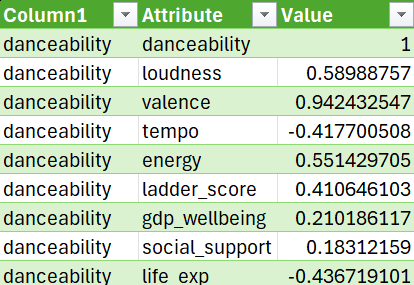

### Analyzing Correlations in the Bottom 10 Happiness Score Countries

= Table.Sort(#“Renamed Columns”,{{“ladder_score”, Order.Descending}})

#### Remove Country names

= Table.SelectRows(#“Filtered Rows3”, each [country] <> null and [country] <> ““)

Matrix calculated using CORREL function in Excel with indexing to repeat according to columns.

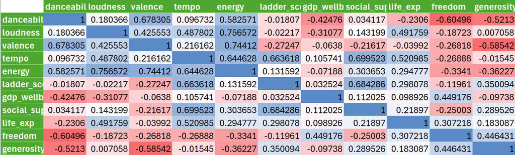

= Table.UnpivotOtherColumns(#“Changed Type”, {“Column1”}, “Attribute”, “Value”)

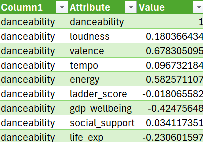

#### Since 2025 Happiness Report is not available yet, we will compare the average of music analytic components and note if there are any changes.

### New Zealand

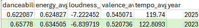

#### Melt combined NZ table

= Table.UnpivotOtherColumns(#“Changed Type”, {“Column1”}, “Attribute”, “Value”)

[figure not shown]

### South Korea

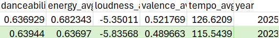

#### Melt combined Korea table

= Table.UnpivotOtherColumns(#“Changed Type”, {“Column1”}, “Attribute”, “Value”)

[figure not shown]

### USA

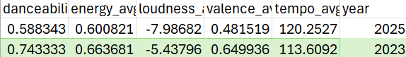

#### Melt combined USA table

= Table.UnpivotOtherColumns(#“Changed Type”, {“Column1”}, “Attribute”, “Value”)

[figure not shown]